# Subsets of Unisex Names

Fiona Devine

4/22/2021

```r
library(tidyverse)
library(stringr)
library(babynames)
library(fivethirtyeight)
```

Str_subset() is able to filter the dataset to pull **values** that match the criteria input in the search. It is important to note that this function will not create a new dataset of its own, but will instead provide only values, which can be compiled into a dataset through other means.

A common way in which str_subset() can be used is by filtering by letters.

- str_subset(data, “n”)
  - Will pull all values from a dataset that include the letter n
- str_subset(data, “n$”)
  - Will pull all values from a dataset that end with the letter n
- str_subset(data, “^n”)
  - Will pull all values from a dataset that begin with the letter n

An example of the use of the str_subset() function is through the unisex_names dataset from the fivethirtyeight package. In western society, I believe we are taught to understand that names ending in vowels are traditionally more feminine than names ending in consonants, which are traditionally read as more masculine. Since my given name ends with an “a” and is usually the thing to clock me by strangers who may otherwise view me as male, I was interested in seeing what unisex names on this list end in the letter “a” as well.

To do this, I began by pulling all the names in the dataset that end with the letter “a” using the str_subset() function.

```r
str_subset(unisex_names$name, "a$")
```

```
##  [1] "Elisha"        "Shea"          "Santana"       "Alva"
##  [5] "Kenyatta"      "Lorenza"       "Alpha"         "Krishna"
##  [9] "Isa"           "Seneca"        "Ara"           "Lakota"
## [13] "Micha"         "Shia"          "Shaya"         "Indiana"
## [17] "Aundra"        "Alika"         "Monta"         "Elza"
## [21] "Bela"          "Pasha"         "Adama"         "Neema"
## [25] "Shiva"         "Makana"        "Uchenna"       "Hoa"
## [29] "Maika"         "Chidera"       "Yona"          "Kijana"
## [33] "Ja"            "Ova"           "Alvia"         "Juda"
## [37] "Elya"          "Da"            "Oluwadamilola" "Deundra"
## [41] "Donyea"        "Mattia"        "Nakota"        "Temiloluwa"
## [45] "Oreoluwa"      "Leotha"        "Olanda"        "Quanta"
## [49] "Soua"          "Lakoda"        "Deondrea"      "Adisa"
## [53] "Nesta"         "Alija"         "Olayinka"      "Inioluwa"
```

By using str_subset() on the name column of unisex_names, and by using “a$” to filter by the last letter “a”, I am left with a list of values from the dataset that fit my criteria of unisex names ending with the letter “a”.

This has resulted in a list of character values pulled from the dataset, and not observations in the dataset itself. Therefore, if I were to try to filter the unisex_names dataset using “filter(str_subset(unisex_names$name, "a$”))", this will not work.

I am interested in seeing columns such as “total”, “male_share”, “female_share”, and “gap” along with the 56 unisex names that end in “a”, so rather than manually filtering the unisex_names dataset by each individual name (ie. “filter(”Elisha“,”Shea“,”Santana“,”Alva", …)), I can create a new separate dataset for just these names alone to work with easier.

```r
a = str_subset(unisex_names$name, "a$") # setting the previous str_subset() function to a name
unisexnames_a <- data.frame(name = c(a)) # creating a dataframe from the list of 56 name values (a) pulled in the previous code
unisexnames_a
```

```
##             name
## 1         Elisha
## 2           Shea
## 3        Santana
## 4           Alva
## 5       Kenyatta
## 6        Lorenza
## 7          Alpha
## 8        Krishna
## 9            Isa
## 10        Seneca
## 11           Ara
## 12        Lakota
## 13         Micha
## 14          Shia
```

[output cut: 42 more lines]

Here, I have created a new dataset from the 56 values that were extracted from the unisex_names dataset, now named unisexnames_a. This just gives a dataset of those 56 names and nothing else.

I am still interested in seeing “total”, “male_share”, “female_share”, and “gap” in regards to these 56 names, so I can now use a join() function to join the unisexnames_a and unisex_names datasets to combine the information.

```r
names_joined = unisexnames_a %>% inner_join(unisex_names, by = "name")
names_joined3 = names_joined %>% top_n(n = 10, wt = total)
names_joined3
```

```
##        name     total male_share female_share        gap
## 1    Elisha 22184.559  0.4233519    0.5766481 0.15329625
## 2      Shea 16768.892  0.4133024    0.5866976 0.17339515
## 3   Santana  7922.714  0.4389050    0.5610950 0.12219000
## 4      Alva  7496.351  0.4726391    0.5273609 0.05472187
## 5  Kenyatta  7063.611  0.4180898    0.5819102 0.16382030
## 6   Lorenza  4249.274  0.5435750    0.4564250 0.08714999
## 7     Alpha  3406.677  0.3809738    0.6190262 0.23805246
## 8   Krishna  3270.049  0.4942404    0.5057596 0.01151915
## 9       Isa  2895.498  0.4661917    0.5338083 0.06761660
## 10   Seneca  2856.367  0.5140984    0.4859016 0.02819687
```

Using an inner_join() on these two datasets with respect to the name category, I now have a new dataset called names_joined that gives me all the columns in the original unisex_names dataset only with respect to unisex names ending with the letter “a”.

This str_subset() function is very useful in finding many different patterns in a dataset. It can be used to pull information out of a dataset in a way that could be difficult to do otherwise.

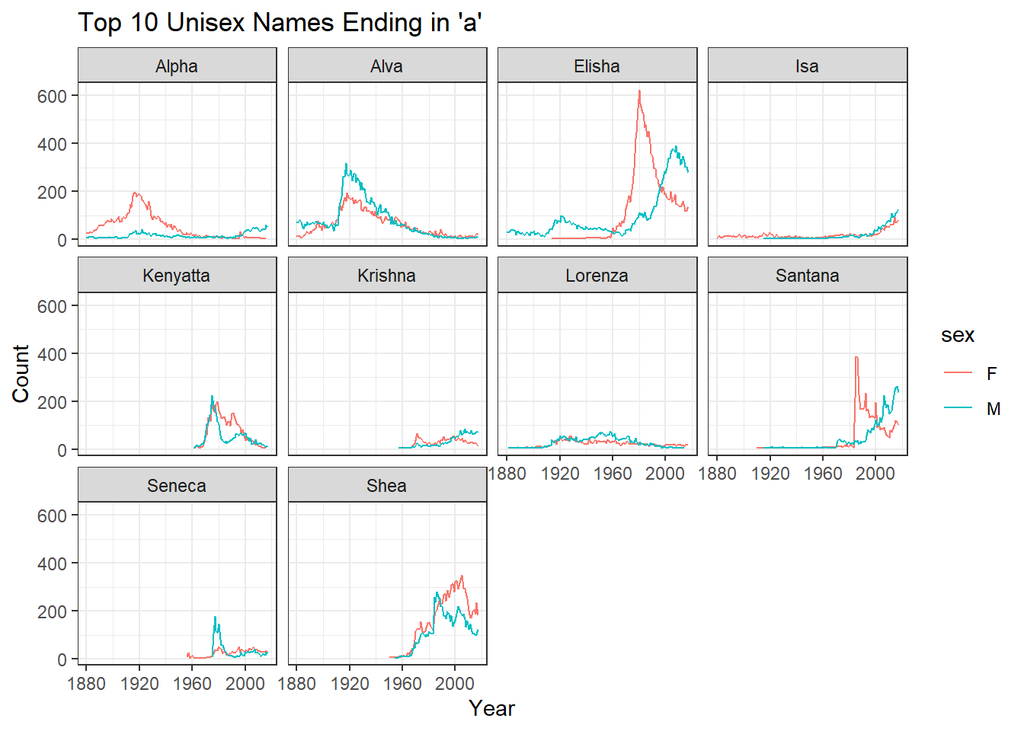

```r
names_joined2 = names_joined3 %>% inner_join(babynames, by = "name")  #filter("Elisha", "Shea", "Santana", "Alva", "Kenyatta", "Lorenza", "Alpha", "Krishna", "Isa", "Seneca")

ggplot(names_joined2, aes(x = year, y = n, color = sex)) + geom_line() + labs(x = "Year", y = "Count", title = "Top 10 Unisex Names Ending in 'a'") + theme_bw() + facet_wrap(~ name)
```